# Improving the quality of training samples

Alicia Valdés

04 marzo 2025

This scripts uses several pre-processing methods to improve the quality of training samples for machine learning classification of satellite images.

Documentation: https://e-sensing.github.io/sitsbook/improving-the-quality-of-training-samples.html

First, the training set should be cross-validated to assess its inherent prediction error (i.e. whether the data is internally consistent). Cross-validation does not predict actual model performance, and thus the quality of traning sets shold be improved using additional tools (HC, SOM, RSI).

# Load libraries

```r
library(dplyr)
library(tibble)
library(purrr)
library(tidyr)
library(sf)
library(sits)
library(kohonen)
library(here)
```

# Load previously saved objects

These objects took a long time to generate!

```r
samples_organized <- readRDS(file = here("r_objects", "samples_organized.rds"))
#cross_val <- readRDS(file = here("r_objects", "cross_val.rds"))
samples_SOM_cluster <- readRDS(here("r_objects", "samples_SOM_cluster.rds"))
samples_SOM_new_cluster <- readRDS(file = here("r_objects", "samples_SOM_new_cluster.rds"))
samples_RSI <- readRDS(here("r_objects", "samples_RSI.rds"))
som_cluster_bal <- readRDS(file = here("r_objects", "som_cluster_bal.rds"))
```

# Data prep

## Implementing csv to Rstudio format

No need to run again if using saved objects!

```r
# Cargamos el csv en la ruta correspondiente.
samples <- read.csv(here("data", "AT_ALPENNINNE.csv"))

# Organizamos en el formato/estructura el csv para que RStudio acepte el formato.

samples_organized <- samples %>%
  pivot_wider(names_from = "band", values_from = "value") %>%  # Volver a formato ancho
  group_by(longitude, latitude, start_date, end_date, label, cube) %>%
  nest(time_series = c(Index, B02, B03, B04, B08, B09, B10))  # Anidar las bandas

samples_organized <- samples_organized %>%
  mutate(time_series = map(time_series, ~ .x %>%
                             # Convertir Index a formato Date
                             mutate(Index = as.Date(Index, format = "%Y-%m-%d"))))

# Accedemos a la primera time_series
samples_organized$time_series[[1]]

# Posiblemente en la integración de los datos puede llegar a haber en ocasiones
# errores en el formato de los campos por lo que nos aseguramos de que cada campo tenga su formato.

samples_organized <- samples_organized %>%
  mutate(
    start_date = as.Date(start_date, format = "%Y-%m-%d"),  # Convertir a formato Date
    end_date = as.Date(end_date, format = "%Y-%m-%d"),      # Convertir a formato Date
    label = as.character(label)  # Convertir a character
  )

saveRDS(samples_organized, file = here("r_objects", "samples_organized.rds"))
```

## Ungroup the samples

We need ungroup() for some algorithms to work.

```r
samples_organized_ungr <- samples_organized %>% ungroup()
```

## Transform to sits class

```r
# Se implementa como un conjunto de datos en formato 'group_dbf' y
# para aplicar los procesamientos que queremos tenemos que transformarlo a 'sits'.
class(samples_organized) <- c("sits", class(samples_organized))
class(samples_organized_ungr) <- c("sits", class(samples_organized_ungr))
```

# Obtaining samples using Rstudio (do not use)

```r
#####________________ COMANDO PARA REALIZAR LA OBTENCIÓN DE LOS SAMPLES MEDIANTE RSTUDIO ________________#####
#####________ SIMPLEMENTE AGREGADO PARA CONOCER COMO SE HA OBTENIDO EL ARCHIVO DATA (NO USADO) __________#####

# Cargamos el datacube en el formato que admite SITS.

datacube <- sits_cube(
  source = "MPC",
  collection = "SENTINEL-2-L2A",
  data_dir = "RUTA/AL/DATACUBE"
)

# Cargamos el shapefile de los puntos que solo deben contener la etiqueta 'label'.

shp_file <- "RUTA/AL/SHAPEFILE.shp"
if (file.exists(shp_file)) {
  sf_shape <- st_read(shp_file)
  print(sf_shape)
} else {
  stop("El archivo no existe en la ruta especificada.")
}
# Obtenemos el samples con el que podemos empezar a realizar los analisis.

samples <- sits_get_data(
  cube         = datacube,
  samples      = sf_shape,
  start_date = "2021-01-01",
  end_date = "2021-12-31",
  progress = TRUE
)
```

# Statistics of samples

Run on samples_organized.

```r
summary(samples_organized)
```

| label | count | prop |
| --- | --- | --- |
| 1 | 11923 | 0.0242524714 |
| 14 | 14760 | 0.0300231886 |
| 15 | 423 | 0.0008604207 |
| 18 | 2385 | 0.0048513079 |
| 27 | 153596 | 0.3124282983 |
| 30 | 12117 | 0.0246470851 |
| 40 | 19932 | 0.0405435092 |
| 41 | 166360 | 0.3383914405 |
| 47 | 214 | 0.0004352956 |
| 48 | 4402 | 0.0089540702 |

[output cut: 6 more lines]

# Get labels, band, head and class of the samples

```r
sits_labels(samples_organized)
```

```
 [1] "1"  "14" "15" "18" "27" "30" "40" "41" "47" "48" "49" "51" "52" "55" "63" "73"
```

```r
sits_bands(samples_organized)
```

```
[1] "B02" "B03" "B04" "B08" "B09" "B10"
```

```r
head(samples_organized)
```

| longitude | latitude | start_date | end_date | label | cube | time_series |
| --- | --- | --- | --- | --- | --- | --- |
| 367475.8 | 4696678 | 2021-01-01 | 2021-12-01 | 41 | SENTINEL-2-L2A |  |
| 367476.3 | 4696681 | 2021-01-01 | 2021-12-01 | 41 | SENTINEL-2-L2A |  |
| 367476.9 | 4696683 | 2021-01-01 | 2021-12-01 | 41 | SENTINEL-2-L2A |  |
| 367478.3 | 4696678 | 2021-01-01 | 2021-12-01 | 41 | SENTINEL-2-L2A |  |
| 367478.8 | 4696680 | 2021-01-01 | 2021-12-01 | 41 | SENTINEL-2-L2A |  |
| 367479.3 | 4696683 | 2021-01-01 | 2021-12-01 | 41 | SENTINEL-2-L2A |  |

```r
class(samples_organized)
```

```
[1] "sits"       "sits"       "grouped_df" "tbl_df"     "tbl"        "data.frame"
```

# Hierarchical cluster (HC) - ERROR

Agglomerative Hierarchical Clustering (AHC). Higher computational complexity than SOM (so maybe SOM better for large data). AHC computes dissimilarity between two elements from a dataset. Decides which two clusters are merged at each iteration.

dist_method: specifies how to calculate the distance between two time series

linkage: defines the distance metric between clusters

To cut the dendrogram, the sits_cluster_dendro() function computes the adjusted rand index (ARI), returning the height where the cut of the dendrogram maximizes the index. The result of sits_cluster_dendro() is a time series tibble with one additional column called “cluster”.

```r
# Realizamos la agrupación que hace HC automáticamente.
# Usamos un 1% de los datos y funciona
# Con 10% sigue dando error!
samples_HC_1 <- sits_cluster_dendro(samples = samples_organized_ungr %>%
                                    sample_frac(0.01),
                                  dist_method = "dtw_basic",
                                  linkage = "ward.D2")
saveRDS(samples_HC_1, file = here("r_objects", "samples_HC_1.rds"))
```

Try with one band only and 5% of the data (with all data still error).

```r
samples_HC_5_1band  <- sits_cluster_dendro(samples = samples_organized_ungr %>%
                                          sample_frac(0.05),
                                        bands = c("B02"),
                                        dist_method = "dtw_basic",
                                        linkage = "ward.D2")
saveRDS(samples_HC_5_1band , file = here("r_objects", "samples_HC_5_1band rds"))
```

Error en matrix(0, x_len * (x_len + diagonal_factor)/2L, 1L): valor de ‘nrow’ no válido (demasiado grande o NA) Además: Aviso: In x_len * (x_len + diagonal_factor) : NAs producidos por enteros excedidos

The function sits_cluster_frequency() provides information on the composition of each cluster. Clusters might have a predominance of one label, or contain a mix of samples from several labels (confusion).

Use dplyr::filter() to remove very “mixed” clusters.

sits_cluster_clean() removes the outliers, leaving only the most frequent label for each cluster. After cleaning the samples, the resulting set of samples is likely to improve the classification results.

```r
sits_cluster_frequency(samples_HC_1)
sits_cluster_frequency(samples_HC_5_1band)

# How to know which cluster to remove? --> The ones with mixes of samples from different labels

# samples_HC_clean <- dplyr::filter(samples_HC, cluster != 4)

# Mostramos la agrupación para observar como se ha clasificado
# y para eliminar el grupo realizado por el cluster sería el siguiente comando:

samples_HC1_clean <- sits_cluster_clean(samples_HC_1) # Leaves very few samples!
samples_HC5_1band_clean <- sits_cluster_clean(samples_HC_5_1band) # Leaves very few samples!
samples_HC1_clean
samples_HC5_1band_clean
```

# Self-organized map (SOM)

## Creating the SOM map

Clustering technique based on self-organizing maps (SOM). It is a dimensionality reduction technique where high-dimensional data is mapped into a two-dimensional map, keeping the topological relations between data patterns. The SOM 2D map is composed of “neurons”. Each neuron has a weight vector, with the same dimension as the training samples. At the start, neurons are assigned a small random value and then trained by competitive learning. The algorithm computes the distances of each member of the training set to all neurons and finds the neuron closest to the input, called the best matching unit.

```r
samples_SOM_cluster <- sits_som_map(samples_organized_ungr,
                                    grid_xdim = 15,
                                    grid_ydim = 15,
                                    alpha = 1.0,
                                    distance = "dtw",
                                    rlen = 20)
# Avisos:
#   1: In sits_som_map(samples_organized_ungr, grid_xdim = 15, grid_ydim = 15,  :
#      recommended values for grid_xdim and grid_ydim are (57 ...62)
#   2: In RcppSupersom(data = data_matrix, codes = init_matrix, numVars = nvar,  :
#      subscript out of bounds (index 1 >= vector size 1)
#   3: In .colors_get(labels = kohonen_obj[["neuron_label"]], legend = NULL,  :
#      missing colors for labels27, 41, 27, 51, 73, 51, 55, 51, 41, 41, 41, 41, 55, 51, 51, 27, 27, 41, 51, 1, 1, 51, 51, 41, 41, 41, 51, 55, 55, 41, 27, 27, 41, 41, 1, 51, 51, 51, 51, 41, 55, 55, 51, 51, 51, 27, 27, 41, 41, 41, 41, 51, 41, 51, 51, 55, 51, 51, 41, 41, 27, 27, 41, 41, 41, 41, 41, 41, 41, 41, 41, 51, 51, 41, 41, 27, 41, 41, 41, 41, 41, 41, 41, 41, 41, 41, 41, 41, 41, 41, 30, 41, 41, 14, 41, 41, 41, 41, 41, 41, 41, 41, 41, 41, 41, 30, 41, 40, 41, 41, 41, 41, 27, 41, 41, 41, 41, 41, 41, 41, 27, 27, 41, 41, 41, 41, 27, 27, 27, 27, 41, 41, 41, 41, 41, 27, 27, 27, 27, 27, 27, 27, 27, 27, 27, 41, 41, 41, 41, 51, 27, 27, 27, 27, 27, 27, 27, 27, 27, 41, 41, 41, 41, 41, 51, 27, 27, 27, 27, 27, 27, 27, 41, 41, 41, 41, 41, 41, 51, 41, 27, 27, 27, 27, 27, 27, 41, 41, 41, 41, 41, 41, 41, 41, 51, 27, 27, 27, 27, 27, 27, 27, 41, 41, 41, 41, 41, 41, 41, 41, 41, 27, 27, 27, 27, 27, 27, 41, 41, 41, 51, 51, 41, 41, 41
#   4: In .colors_get(labels = kohonen_obj[["neuron_label"]], legend = NULL,  : palette for missing colors isSet3
saveRDS(samples_SOM_cluster, file = here("r_objects", "samples_SOM_cluster.rds"))
```

Plots for the SOM map (different bands).

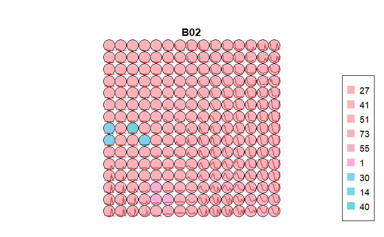

```r
plot(samples_SOM_cluster, band = "B02")
```

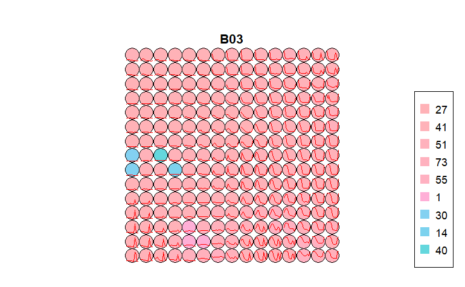

```r
plot(samples_SOM_cluster, band = "B03")
```

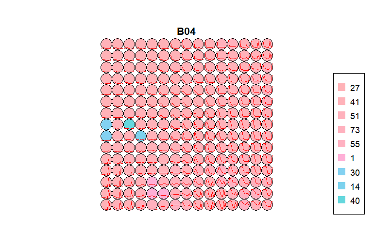

```r
plot(samples_SOM_cluster, band = "B04")
```

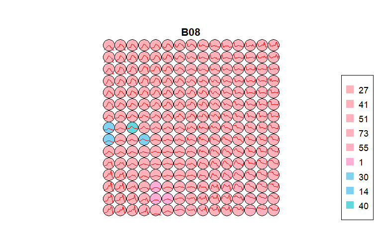

```r
plot(samples_SOM_cluster, band = "B08")
```

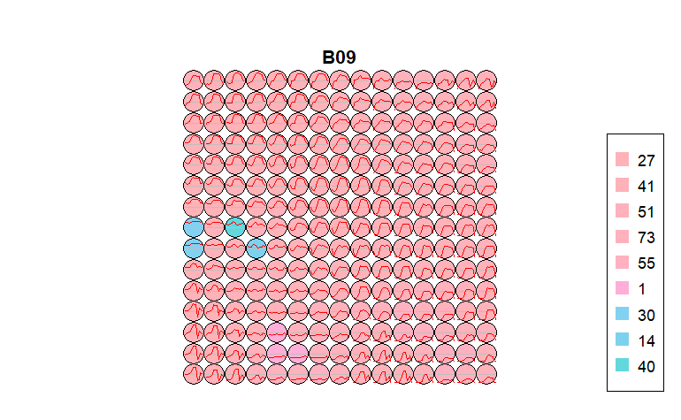

```r
plot(samples_SOM_cluster, band = "B09")
```

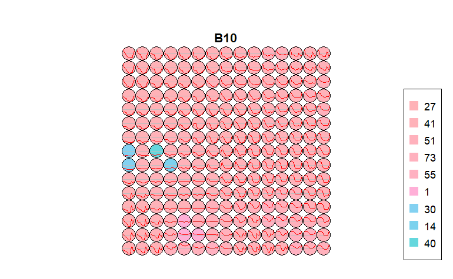

```r
plot(samples_SOM_cluster, band = "B10")
```

See what to do with warning about the colors - not sure why the labels have so similar colors in the plot. Might need to change the color palette, but not sure how.

## Measuring confusion between labels using SOM

The function sits_som_evaluate_cluster() groups neurons by their majority label and produces a tibble. Neurons are grouped into clusters, and there will be as many clusters as there are labels. The results shows the percentage of samples of each label in each cluster. Ideally, all samples of each cluster would have the same label. In practice, clusters contain samples with different labels. This information helps on measuring the confusion between samples.

```r
som_eval <- sits_som_evaluate_cluster(samples_SOM_cluster) # Lo evaluamos.
```

Plot confusion between clusters.

```r
som_eval
```

| id_cluster | cluster | class | mixture_percentage |
| --- | --- | --- | --- |
| 1 | 1 | 1 | 43.111294994 |
| 1 | 1 | 14 | 2.544476624 |
| 1 | 1 | 15 | 0.041373604 |
| 1 | 1 | 18 | 0.351675631 |
| 1 | 1 | 27 | 1.282581713 |
| 1 | 1 | 30 | 1.365328920 |
| 1 | 1 | 40 | 1.551510137 |
| 1 | 1 | 41 | 14.604882085 |
| 1 | 1 | 48 | 0.413736036 |
| 1 | 1 | 49 | 1.117087298 |

[output cut: 112 more lines]

```
Aviso: missing colors for labels1, 14, 15, 18, 27, 30, 40, 41, 48, 49, 51, 52, 55, 63, 73, 47Aviso: palette for missing colors isSet3
```

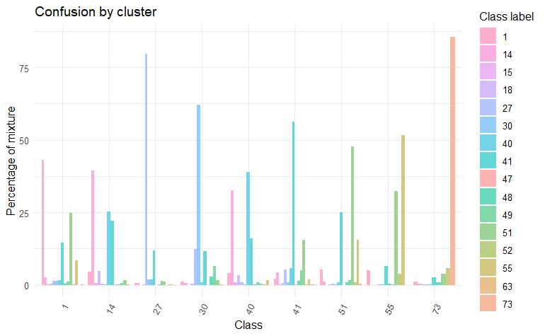

```r
plot(som_eval)
```

Some classes missing in the above plot (there are 16 and only 9 are shown) - might have to do with warning about missing colors.

## Detecting noisy samples using SOM

This approach uses the discrete probability distribution associated with each neuron, which is included in the labeled_neurons tibble produced by sits_som_map(). This approach associates probabilities with frequency of occurrence. More homogeneous neurons (those with one label has high frequency) are assumed to be composed of good quality samples. Heterogeneous neurons (those with two or more classes with significant frequencies) are likely to contain noisy samples.

The function sits_som_clean_samples() finds out which samples are noisy, which are clean, and which need to be further examined by the user.

If the prior probability of a sample is less than prior_threshold, the sample is assumed to be noisy and tagged as “remove”.

If the prior probability is greater or equal to prior_threshold and the posterior probability calculated by Bayesian inference is greater or equal to posterior_threshold, the sample is assumed not to be noisy and thus is tagged as “clean”.

If the prior probability is greater or equal to prior_threshold and the posterior probability is less than posterior_threshold, we have a situation when the sample is part of the majority level of those assigned to its neuron, but its label is not consistent with most of its neighbors. This is an anomalous condition and is tagged as “analyze”. Users are encouraged to inspect such samples to find out whether they are in fact noisy or not.

The default value for both prior_threshold and posterior_threshold is 60%.

The sits_som_clean_samples() has an additional parameter (keep), which indicates which samples should be kept in the set based on their prior and posterior probabilities. The default for keep is c(“clean”, “analyze”).

```r
samples_SOM_02_02 <- sits_som_clean_samples(
  som_map = samples_SOM_cluster,
  prior_threshold = 0.2,
  posterior_threshold = 0.2,
  keep = c("clean", "analyze")
)
samples_SOM_02_04 <- sits_som_clean_samples(
  som_map = samples_SOM_cluster,
  prior_threshold = 0.2,
  posterior_threshold = 0.4,
  keep = c("clean", "analyze")
)
samples_SOM_02_06 <- sits_som_clean_samples(
  som_map = samples_SOM_cluster,
  prior_threshold = 0.2,
  posterior_threshold = 0.6,
  keep = c("clean", "analyze")
)
samples_SOM_02_08 <- sits_som_clean_samples(
  som_map = samples_SOM_cluster,
  prior_threshold = 0.2,
  posterior_threshold = 0.8,
  keep = c("clean", "analyze")
)
samples_SOM_04_02 <- sits_som_clean_samples(
  som_map = samples_SOM_cluster,
  prior_threshold = 0.4,
  posterior_threshold = 0.2,
  keep = c("clean", "analyze")
)
samples_SOM_04_04 <- sits_som_clean_samples(
  som_map = samples_SOM_cluster,
  prior_threshold = 0.4,
  posterior_threshold = 0.4,
  keep = c("clean", "analyze")
)
samples_SOM_04_06 <- sits_som_clean_samples(
  som_map = samples_SOM_cluster,
  prior_threshold = 0.4,
  posterior_threshold = 0.6,
  keep = c("clean", "analyze")
)
samples_SOM_04_08 <- sits_som_clean_samples(
  som_map = samples_SOM_cluster,
  prior_threshold = 0.4,
  posterior_threshold = 0.8,
  keep = c("clean", "analyze")
)
samples_SOM_06_02 <- sits_som_clean_samples(
  som_map = samples_SOM_cluster,
  prior_threshold = 0.6,
  posterior_threshold = 0.2,
  keep = c("clean", "analyze")
)
samples_SOM_06_04 <- sits_som_clean_samples(
  som_map = samples_SOM_cluster,
  prior_threshold = 0.6,
  posterior_threshold = 0.4,
  keep = c("clean", "analyze")
)
samples_SOM_06_06 <- sits_som_clean_samples(
  som_map = samples_SOM_cluster,
  prior_threshold = 0.6,
  posterior_threshold = 0.6,
  keep = c("clean", "analyze")
)
samples_SOM_06_08 <- sits_som_clean_samples(
  som_map = samples_SOM_cluster,
  prior_threshold = 0.6,
  posterior_threshold = 0.8,
  keep = c("clean", "analyze")
)
samples_SOM_08_02 <- sits_som_clean_samples(
  som_map = samples_SOM_cluster,
  prior_threshold = 0.8,
  posterior_threshold = 0.2,
  keep = c("clean", "analyze")
)
samples_SOM_08_04 <- sits_som_clean_samples(
  som_map = samples_SOM_cluster,
  prior_threshold = 0.8,
  posterior_threshold = 0.4,
  keep = c("clean", "analyze")
)
samples_SOM_08_06 <- sits_som_clean_samples(
  som_map = samples_SOM_cluster,
  prior_threshold = 0.8,
  posterior_threshold = 0.6,
  keep = c("clean", "analyze")
)
samples_SOM_08_08 <- sits_som_clean_samples(
  som_map = samples_SOM_cluster,
  prior_threshold = 0.8,
  posterior_threshold = 0.8,
  keep = c("clean", "analyze")
)
```

```r
summary(samples_SOM_02_02)
```

| label | count | prop |
| --- | --- | --- |
| 1 | 4043 | 0.010795353 |
| 14 | 4947 | 0.013209154 |
| 27 | 143925 | 0.384299076 |
| 30 | 6588 | 0.017590845 |
| 40 | 4647 | 0.012408114 |
| 41 | 149032 | 0.397935452 |
| 49 | 568 | 0.001516636 |
| 51 | 48425 | 0.129301253 |
| 55 | 10442 | 0.027881542 |
| 73 | 1896 | 0.005062575 |

```r
summary(samples_SOM_02_04)
```

| label | count | prop |
| --- | --- | --- |
| 1 | 4043 | 0.010795353 |
| 14 | 4947 | 0.013209154 |
| 27 | 143925 | 0.384299076 |
| 30 | 6588 | 0.017590845 |
| 40 | 4647 | 0.012408114 |
| 41 | 149032 | 0.397935452 |
| 49 | 568 | 0.001516636 |
| 51 | 48425 | 0.129301253 |
| 55 | 10442 | 0.027881542 |
| 73 | 1896 | 0.005062575 |

```r
summary(samples_SOM_02_06)
```

| label | count | prop |
| --- | --- | --- |
| 1 | 4043 | 0.010795353 |
| 14 | 4947 | 0.013209154 |
| 27 | 143925 | 0.384299076 |
| 30 | 6588 | 0.017590845 |
| 40 | 4647 | 0.012408114 |
| 41 | 149032 | 0.397935452 |
| 49 | 568 | 0.001516636 |
| 51 | 48425 | 0.129301253 |
| 55 | 10442 | 0.027881542 |
| 73 | 1896 | 0.005062575 |

```r
summary(samples_SOM_02_08)
```

| label | count | prop |
| --- | --- | --- |
| 1 | 4043 | 0.010795353 |
| 14 | 4947 | 0.013209154 |
| 27 | 143925 | 0.384299076 |
| 30 | 6588 | 0.017590845 |
| 40 | 4647 | 0.012408114 |
| 41 | 149032 | 0.397935452 |
| 49 | 568 | 0.001516636 |
| 51 | 48425 | 0.129301253 |
| 55 | 10442 | 0.027881542 |
| 73 | 1896 | 0.005062575 |

```r
summary(samples_SOM_04_02)
```

| label | count | prop |
| --- | --- | --- |
| 1 | 1565 | 0.005245957 |
| 27 | 138771 | 0.465167183 |
| 30 | 6588 | 0.022083298 |
| 41 | 120075 | 0.402497276 |
| 51 | 23153 | 0.077609989 |
| 55 | 6277 | 0.021040811 |
| 73 | 1896 | 0.006355485 |

```r
summary(samples_SOM_04_04)
```

| label | count | prop |
| --- | --- | --- |
| 1 | 1565 | 0.005245957 |
| 27 | 138771 | 0.465167183 |
| 30 | 6588 | 0.022083298 |
| 41 | 120075 | 0.402497276 |
| 51 | 23153 | 0.077609989 |
| 55 | 6277 | 0.021040811 |
| 73 | 1896 | 0.006355485 |

```r
summary(samples_SOM_04_06)
```

| label | count | prop |
| --- | --- | --- |
| 1 | 1565 | 0.005245957 |
| 27 | 138771 | 0.465167183 |
| 30 | 6588 | 0.022083298 |
| 41 | 120075 | 0.402497276 |
| 51 | 23153 | 0.077609989 |
| 55 | 6277 | 0.021040811 |
| 73 | 1896 | 0.006355485 |

```r
summary(samples_SOM_04_08)
```

| label | count | prop |
| --- | --- | --- |
| 1 | 1565 | 0.005245957 |
| 27 | 138771 | 0.465167183 |
| 30 | 6588 | 0.022083298 |
| 41 | 120075 | 0.402497276 |
| 51 | 23153 | 0.077609989 |
| 55 | 6277 | 0.021040811 |
| 73 | 1896 | 0.006355485 |

```r
summary(samples_SOM_06_02)
```

| label | count | prop |
| --- | --- | --- |
| 27 | 129555 | 0.637799811 |
| 30 | 4982 | 0.024526407 |
| 41 | 65620 | 0.323047537 |
| 51 | 1075 | 0.005292230 |
| 73 | 1896 | 0.009334016 |

```r
summary(samples_SOM_06_04)
```

| label | count | prop |
| --- | --- | --- |
| 27 | 129555 | 0.637799811 |
| 30 | 4982 | 0.024526407 |
| 41 | 65620 | 0.323047537 |
| 51 | 1075 | 0.005292230 |
| 73 | 1896 | 0.009334016 |

```r
summary(samples_SOM_06_06)
```

| label | count | prop |
| --- | --- | --- |
| 27 | 129555 | 0.637799811 |
| 30 | 4982 | 0.024526407 |
| 41 | 65620 | 0.323047537 |
| 51 | 1075 | 0.005292230 |
| 73 | 1896 | 0.009334016 |

```r
summary(samples_SOM_06_08)
```

| label | count | prop |
| --- | --- | --- |
| 27 | 129555 | 0.637799811 |
| 30 | 4982 | 0.024526407 |
| 41 | 65620 | 0.323047537 |
| 51 | 1075 | 0.005292230 |
| 73 | 1896 | 0.009334016 |

```r
summary(samples_SOM_08_02)
```

| label | count | prop |
| --- | --- | --- |
| 27 | 99373 | 0.91643765 |
| 41 | 7165 | 0.06607706 |
| 73 | 1896 | 0.01748529 |

```r
summary(samples_SOM_08_04)
```

| label | count | prop |
| --- | --- | --- |
| 27 | 99373 | 0.91643765 |
| 41 | 7165 | 0.06607706 |
| 73 | 1896 | 0.01748529 |

```r
summary(samples_SOM_08_06)
```

| label | count | prop |
| --- | --- | --- |
| 27 | 99373 | 0.91643765 |
| 41 | 7165 | 0.06607706 |
| 73 | 1896 | 0.01748529 |

```r
summary(samples_SOM_08_08)
```

| label | count | prop |
| --- | --- | --- |
| 27 | 99373 | 0.91643765 |
| 41 | 7165 | 0.06607706 |
| 73 | 1896 | 0.01748529 |

This removes some / many labels!

This is probably because samples of classes which had highest confusion with others have been removed.

How many to analyze / clean?

```r
samples_SOM_06_06 %>% count(eval)
```

| eval | n |
| --- | --- |
| analyze | 81775 |
| clean | 121353 |

Further analysis includes calculating the SOM map and confusion matrix for the new set.

## Create the new SOM maps

Evaluate the mixture in the SOM clusters of new samples.

```r
samples_SOM_new_cluster_02_02 <- sits_som_map(
  data = samples_SOM_02_02,
  grid_xdim = 15,
  grid_ydim = 15,
  alpha = 1.0,
  rlen = 20,
  distance = "dtw"
)

saveRDS(samples_SOM_new_cluster_02_02, file = here("r_objects", "samples_SOM_new_cluster_02_02.rds"))
```

```r
samples_SOM_new_cluster_02_04 <- sits_som_map(
  data = samples_SOM_02_04,
  grid_xdim = 15,
  grid_ydim = 15,
  alpha = 1.0,
  rlen = 20,
  distance = "dtw"
)

saveRDS(samples_SOM_new_cluster_02_04, file = here("r_objects", "samples_SOM_new_cluster_02_04.rds"))
```

```r
samples_SOM_new_cluster_02_06 <- sits_som_map(
  data = samples_SOM_02_06,
  grid_xdim = 15,
  grid_ydim = 15,
  alpha = 1.0,
  rlen = 20,
  distance = "dtw"
)

saveRDS(samples_SOM_new_cluster_02_06, file = here("r_objects", "samples_SOM_new_cluster_02_06.rds"))
```

```r
samples_SOM_new_cluster_02_08 <- sits_som_map(
  data = samples_SOM_02_08,
  grid_xdim = 15,
  grid_ydim = 15,
  alpha = 1.0,
  rlen = 20,
  distance = "dtw"
)

saveRDS(samples_SOM_new_cluster_02_08, file = here("r_objects", "samples_SOM_new_cluster_02_08.rds"))
```

```r
samples_SOM_new_cluster_04_02 <- sits_som_map(
  data = samples_SOM_04_02,
  grid_xdim = 15,
  grid_ydim = 15,
  alpha = 1.0,
  rlen = 20,
  distance = "dtw"
)

saveRDS(samples_SOM_new_cluster_04_02, file = here("r_objects", "samples_SOM_new_cluster_04_02.rds"))
```

```r
samples_SOM_new_cluster_04_04 <- sits_som_map(
  data = samples_SOM_04_04,
  grid_xdim = 15,
  grid_ydim = 15,
  alpha = 1.0,
  rlen = 20,
  distance = "dtw"
)

saveRDS(samples_SOM_new_cluster_04_04, file = here("r_objects", "samples_SOM_new_cluster_04_04.rds"))
```

```r
samples_SOM_new_cluster_04_06 <- sits_som_map(
  data = samples_SOM_04_06,
  grid_xdim = 15,
  grid_ydim = 15,
  alpha = 1.0,
  rlen = 20,
  distance = "dtw"
)

saveRDS(samples_SOM_new_cluster_04_06, file = here("r_objects", "samples_SOM_new_cluster_04_06.rds"))
```

```r
samples_SOM_new_cluster_04_08 <- sits_som_map(
  data = samples_SOM_04_08,
  grid_xdim = 15,
  grid_ydim = 15,
  alpha = 1.0,
  rlen = 20,
  distance = "dtw"
)

saveRDS(samples_SOM_new_cluster_04_08, file = here("r_objects", "samples_SOM_new_cluster_04_08.rds"))
```

```r
samples_SOM_new_cluster_06_02 <- sits_som_map(
  data = samples_SOM_06_02,
  grid_xdim = 15,
  grid_ydim = 15,
  alpha = 1.0,
  rlen = 20,
  distance = "dtw"
)

saveRDS(samples_SOM_new_cluster_06_02, file = here("r_objects", "samples_SOM_new_cluster_06_02.rds"))
```

```r
samples_SOM_new_cluster_06_04 <- sits_som_map(
  data = samples_SOM_06_04,
  grid_xdim = 15,
  grid_ydim = 15,
  alpha = 1.0,
  rlen = 20,
  distance = "dtw"
)

saveRDS(samples_SOM_new_cluster_06_04, file = here("r_objects", "samples_SOM_new_cluster_06_04.rds"))
```

```r
samples_SOM_new_cluster_06_06 <- sits_som_map(
  data = samples_SOM_06_06,
  grid_xdim = 15,
  grid_ydim = 15,
  alpha = 1.0,
  rlen = 20,
  distance = "dtw"
)

saveRDS(samples_SOM_new_cluster_06_06, file = here("r_objects", "samples_SOM_new_cluster_06_06.rds"))
```

```r
samples_SOM_new_cluster_06_08 <- sits_som_map(
  data = samples_SOM_06_08,
  grid_xdim = 15,
  grid_ydim = 15,
  alpha = 1.0,
  rlen = 20,
  distance = "dtw"
)

saveRDS(samples_SOM_new_cluster_06_08, file = here("r_objects", "samples_SOM_new_cluster_06_08.rds"))
```

```r
samples_SOM_new_cluster_08_02 <- sits_som_map(
  data = samples_SOM_08_02,
  grid_xdim = 15,
  grid_ydim = 15,
  alpha = 1.0,
  rlen = 20,
  distance = "dtw"
)

saveRDS(samples_SOM_new_cluster_08_02, file = here("r_objects", "samples_SOM_new_cluster_08_02.rds"))
```

```r
samples_SOM_new_cluster_08_04 <- sits_som_map(
  data = samples_SOM_08_04,
  grid_xdim = 15,
  grid_ydim = 15,
  alpha = 1.0,
  rlen = 20,
  distance = "dtw"
)

saveRDS(samples_SOM_new_cluster_08_04, file = here("r_objects", "samples_SOM_new_cluster_08_04.rds"))
```

```r
samples_SOM_new_cluster_08_06 <- sits_som_map(
  data = samples_SOM_08_06,
  grid_xdim = 15,
  grid_ydim = 15,
  alpha = 1.0,
  rlen = 20,
  distance = "dtw"
)

saveRDS(samples_SOM_new_cluster_08_06, file = here("r_objects", "samples_SOM_new_cluster_08_06.rds"))
```

```r
samples_SOM_new_cluster_08_08 <- sits_som_map(
  data = samples_SOM_08_08,
  grid_xdim = 15,
  grid_ydim = 15,
  alpha = 1.0,
  rlen = 20,
  distance = "dtw"
)

saveRDS(samples_SOM_new_cluster_08_08, file = here("r_objects", "samples_SOM_new_cluster_08_08.rds"))
```

Plots for the new SOM maps

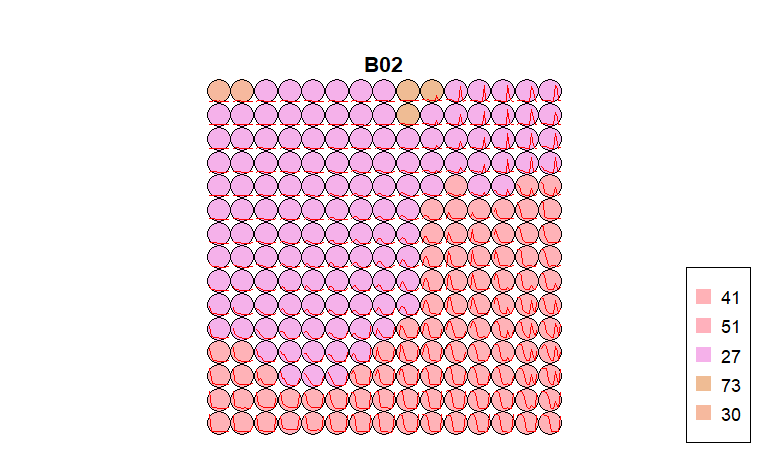

```r
plot(samples_SOM_new_cluster_06_06)
```

Same problem with colors here.

## Measuring confusion between labels using the new SOM map

```r
new_som_eval_02_02 <- sits_som_evaluate_cluster(samples_SOM_new_cluster_02_02)
new_som_eval_02_04 <- sits_som_evaluate_cluster(samples_SOM_new_cluster_02_04)
new_som_eval_02_06 <- sits_som_evaluate_cluster(samples_SOM_new_cluster_02_06)
new_som_eval_02_08 <- sits_som_evaluate_cluster(samples_SOM_new_cluster_02_08)
new_som_eval_04_02 <- sits_som_evaluate_cluster(samples_SOM_new_cluster_04_02)
new_som_eval_04_04 <- sits_som_evaluate_cluster(samples_SOM_new_cluster_04_04)
new_som_eval_04_06 <- sits_som_evaluate_cluster(samples_SOM_new_cluster_04_06)
new_som_eval_04_08 <- sits_som_evaluate_cluster(samples_SOM_new_cluster_04_08)
new_som_eval_06_02 <- sits_som_evaluate_cluster(samples_SOM_new_cluster_06_02)
new_som_eval_06_04 <- sits_som_evaluate_cluster(samples_SOM_new_cluster_06_04)
new_som_eval_06_06 <- sits_som_evaluate_cluster(samples_SOM_new_cluster_06_06)
new_som_eval_06_08 <- sits_som_evaluate_cluster(samples_SOM_new_cluster_06_08)
new_som_eval_08_02 <- sits_som_evaluate_cluster(samples_SOM_new_cluster_08_02)
new_som_eval_08_04 <- sits_som_evaluate_cluster(samples_SOM_new_cluster_08_04)
new_som_eval_08_06 <- sits_som_evaluate_cluster(samples_SOM_new_cluster_08_06)
new_som_eval_08_08 <- sits_som_evaluate_cluster(samples_SOM_new_cluster_08_08)
```

Plot confusion between clusters.

```r
# Plot the confusion between clusters
plot(new_som_eval_02_02)
plot(new_som_eval_02_04)
plot(new_som_eval_02_06)
plot(new_som_eval_02_08)
plot(new_som_eval_04_02)
plot(new_som_eval_04_04)
plot(new_som_eval_04_06)
plot(new_som_eval_04_08)
plot(new_som_eval_06_02)
plot(new_som_eval_06_04)
plot(new_som_eval_06_06)
plot(new_som_eval_06_08)
plot(new_som_eval_08_02)
plot(new_som_eval_08_04)
plot(new_som_eval_08_06)
plot(new_som_eval_08_08)
```

[output not shown]

# Reduce sample imbalance (RSI)

Sample imbalance is an undesirable property of a training set since machine learning algorithms tend to be more accurate for classes with many samples. The instances belonging to the minority group are misclassified more often than those belonging to the majority group. Thus, reducing sample imbalance can positively affect classification accuracy. The function sits_reduce_imbalance() deals with training set imbalance; it increases the number of samples of least frequent labels, and reduces the number of samples of most frequent labels.

```r
summary(samples_organized_ungr)
```

| label | count | prop |
| --- | --- | --- |
| 1 | 11923 | 0.0242524714 |
| 14 | 14760 | 0.0300231886 |
| 15 | 423 | 0.0008604207 |
| 18 | 2385 | 0.0048513079 |
| 27 | 153596 | 0.3124282983 |
| 30 | 12117 | 0.0246470851 |
| 40 | 19932 | 0.0405435092 |
| 41 | 166360 | 0.3383914405 |
| 47 | 214 | 0.0004352956 |
| 48 | 4402 | 0.0089540702 |

[output cut: 6 more lines]

```r
# Aplicamos los parámetros correctos de "máximo" y "mínimo" para reducir el samples.

samples_RSI <- sits_reduce_imbalance(
  samples = samples_organized_ungr,
  n_samples_over = 200, # Min. number of samples per class. Changed (min count was 214)
  n_samples_under = 2000, # Max. number of samples per class. Changed
  multicores = 12
)

saveRDS(samples_RSI, file = here("r_objects", "samples_RSI.rds"))
```

Print the balanced samples.

```r
summary(samples_RSI)
```

| label | count | prop |
| --- | --- | --- |
| 1 | 2116 | 0.080233572 |
| 14 | 2100 | 0.079626891 |
| 15 | 423 | 0.016039131 |
| 18 | 1936 | 0.073408410 |
| 27 | 2116 | 0.080233572 |
| 30 | 2088 | 0.079171880 |
| 40 | 2096 | 0.079475221 |
| 41 | 2116 | 0.080233572 |
| 47 | 214 | 0.008114359 |
| 48 | 2000 | 0.075835134 |

[output cut: 6 more lines]

## Creating the SOM map

```r
som_cluster_bal <- sits_som_map(
  data = samples_RSI,
  grid_xdim = 15,
  grid_ydim = 15,
  alpha = 1.0,
  distance = "dtw",
  rlen = 20,
  mode = "pbatch" # Not sure why this one, from https://e-sensing.github.io/sitsbook/improving-the-quality-of-training-samples.html
  )

saveRDS(som_cluster_bal, file = here("r_objects", "som_cluster_bal.rds"))
```

Plots.

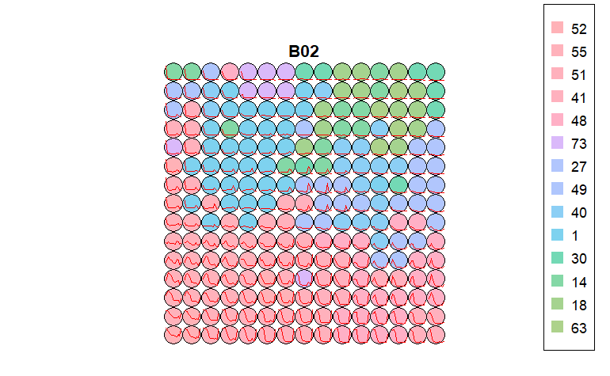

```r
plot(som_cluster_bal, band = "B02")
```

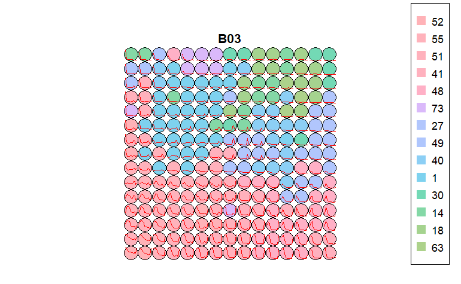

```r
plot(som_cluster_bal, band = "B03")
```

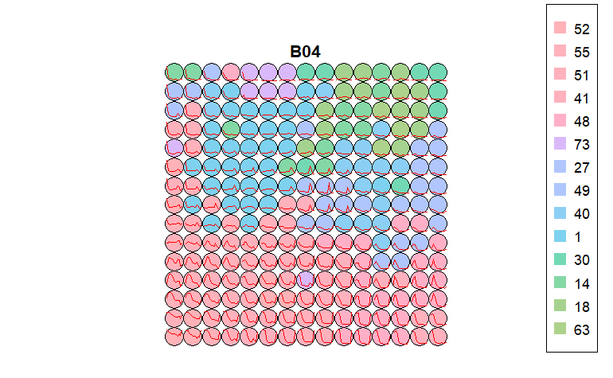

```r
plot(som_cluster_bal, band = "B04")
```

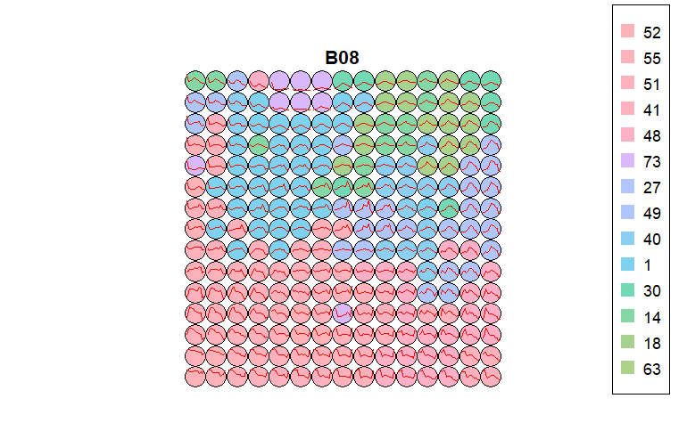

```r
plot(som_cluster_bal, band = "B08")
```

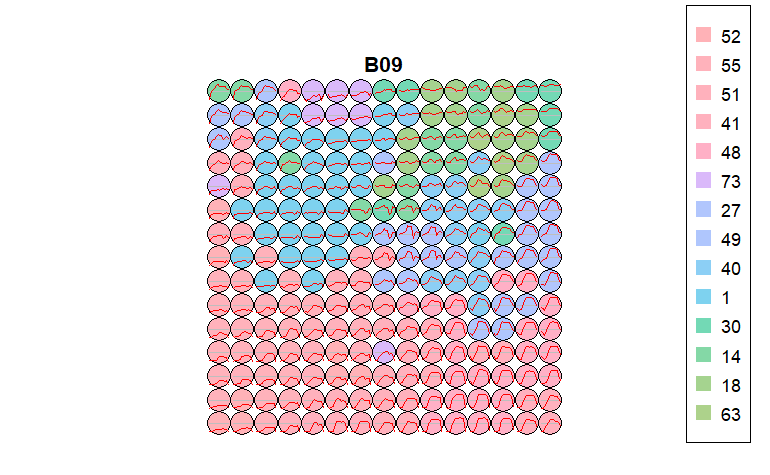

```r
plot(som_cluster_bal, band = "B09")
```

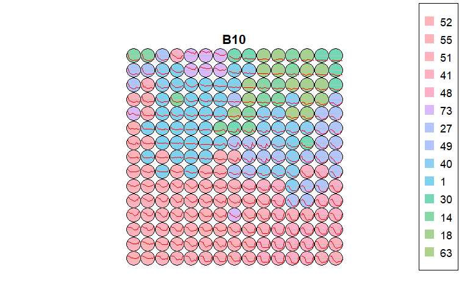

```r
plot(som_cluster_bal, band = "B10")
```

## Measuring confusion between labels using SOM

Produce a tibble with a summary of the mixed labels.

```r
som_eval_RSI <- sits_som_evaluate_cluster(som_cluster_bal)
```

Plot confusion between clusters.

```r
som_eval_RSI
```

| id_cluster | cluster | class | mixture_percentage |
| --- | --- | --- | --- |
| 1 | 1 | 1 | 44.31239389 |
| 1 | 1 | 14 | 6.40916808 |
| 1 | 1 | 15 | 0.38200340 |
| 1 | 1 | 18 | 2.12224109 |
| 1 | 1 | 27 | 0.50933786 |
| 1 | 1 | 30 | 3.09847199 |
| 1 | 1 | 40 | 5.77249576 |
| 1 | 1 | 41 | 4.07470289 |
| 1 | 1 | 47 | 1.23089983 |
| 1 | 1 | 48 | 3.52292020 |

[output cut: 182 more lines]

```
Aviso: missing colors for labels1, 14, 15, 18, 27, 30, 40, 41, 47, 48, 49, 51, 52, 55, 73, 63Aviso: palette for missing colors isSet3
```

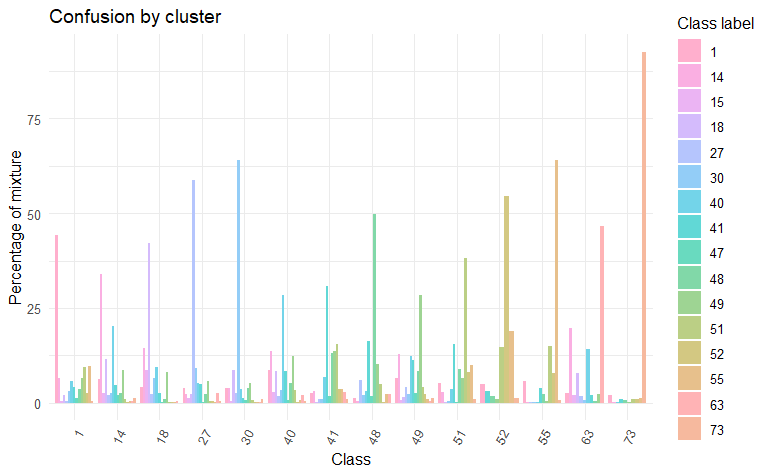

```r
plot(som_eval_RSI)
```

Again warning about colors and missing labels on the graph.

# Cross-validation

## Original dataset

Estimates the inherent prediction error of a model. Uses only the training samples. It is a measure of model performance on the training data, and not an estimate of overall map accuracy. Uses part of the available samples to fit the classification model and a different part to test it.

```r
# Cross-validation (uncertainties)
# Default: validation_split = 0.2 (proportion of original time series set to be used for validation)
# Default: Machine learning method (sits_rfor())
# There is also sits_kfold_validate
# https://e-sensing.github.io/sitsbook/improving-the-quality-of-training-samples.html#cross-validation-of-training-sets

cross_val <- sits_validate(samples_organized)
saveRDS(cross_val, file = here("r_objects", "cross_val.rds"))

# Shows ca. 80% accuracy
# However, this accuracy does not guarantee a good classification result.
# It only shows if the training data is internally consistent.
# (https://e-sensing.github.io/sitsbook/improving-the-quality-of-training-samples.html)
```

Show the result.

```r
cross_val
```

```
Confusion Matrix and Statistics

          Reference
Prediction     1    14    15    18    27    30    40    41    47    48    49    51    52    55
        1   1253    42     2    11    29     8    34    57     0     0    17    69     4    33
        14    58  1927     2    50    19     0    66    57     0     1     3     4     0     0
        15     0     0    54     0     0     0     0     0     0     0     0     0     0     0
        18     1    13     1   140     1     0     2     2     0     0     0     1     0     0
        27   134   130     3    48 29021   352   418  2278     2    32   270   225     3    36
        30    11     6     0     5   167  1740     6   158     3    53    90    35     0     3
        40    71    87     6    18    24     0  1991    68     0     0    13     5     0     0
        41   595   713    17   192  1358   265  1442 28900    28   364  1860  3737    28   441
        47     0     0     0     0     0     0     0     0     1     0     0     0     0     0
        48     0     0     0     0     6     8     0    12     2   341     0     4     0     3
        49     4     5     0     4    10    27     2    73     4     1   615    44     0     2
        51   230    29     0     9    83    23    25  1600     3    80   260  8984    55  1039
        52     0     0     0     0     0     0     0     1     0     0     0     1   116     0
        55    27     0     0     0     1     0     0    66     0     8     1   178    18  2281
        63     0     0     0     0     0     0     0     0     0     0     0     0     0     0
        73     1     0     0     0     0     0     0     0     0     0     0     0     0     0
          Reference
Prediction    63    73
        1      0     1
        14     0     0
        15     0     0
        18     0     0
        27     2     5
        30     0     0
        40     4     0
        41    16    14
        47     0     0
        48     0     0
        49     0     1
        51     0     6
        52     0     0
        55     0     0
        63    97     0
        73     0   478

Overall Statistics
```

[output cut: 24 more lines]

```
Pos Pred Value          0.7230 1.000e+00  0.906915  0.776515   0.72300  0.983051   0.88411
Neg Pred Value          0.9251 9.996e-01  0.994497  0.974224   0.94991  0.998900   0.98374
Prevalence              0.3384 4.373e-04  0.008950  0.031823   0.13513  0.002278   0.03903
Detection Rate          0.2939 1.017e-05  0.003468  0.006255   0.09137  0.001180   0.02320
Detection Prevalence    0.4065 1.017e-05  0.003824  0.008055   0.12638  0.001200   0.02624
Balanced Accuracy       0.8492 5.116e-01  0.693570  0.597345   0.81784  0.758918   0.79558
                     Class: 63 Class: 73
Sensitivity          0.8151261  0.946535
Specificity          1.0000000  0.999990
Pos Pred Value       1.0000000  0.997912
Neg Pred Value       0.9997760  0.999724
Prevalence           0.0012103  0.005136
Detection Rate       0.0009865  0.004861
Detection Prevalence 0.0009865  0.004872
Balanced Accuracy    0.9075630  0.973262
```

A high accuracy here does not guarantee a good classification result. It only shows if the training data is internally consistent. Cross-validation measures how well the model fits the training data. Using these results to measure classification accuracy is only valid if the training data is a good sample of the entire dataset.

## HC: TBD

## SOM

```r
cross_val_SOM_02_02
```

```
Confusion Matrix and Statistics

          Reference
Prediction     1    14    27    30    40    41    49    51    55    73
        1    673     0     0     0     0    18     0    42     7     0
        14     0   801     3     0    37    27     0     0     0     0
        27     0     0 28260    33     0   835     0     1     0     0
        30     0     0     5  1264     0    18     3     0     0     0
        40     0    36     0     0   753    12     0     0     0     0
        41    31   152   516    21   139 27619    84  2168    32     0
        49     0     0     0     0     0     5    27     0     0     0
        51    93     0     1     0     0  1267     0  7320   397     0
        55    12     0     0     0     0     5     0   154  1652     0
        73     0     0     0     0     0     0     0     0     0   379

Overall Statistics

               Accuracy : 0.9178
                 95% CI : (0.9158, 0.9198)
    No Information Rate : 0.3979
    P-Value [Acc > NIR] : < 2.2e-16

                  Kappa : 0.8774

 Mcnemar's Test P-Value : NA

Statistics by Class:

                     Class: 1 Class: 14 Class: 27 Class: 30 Class: 40 Class: 41 Class: 49
Sensitivity          0.831891   0.80991    0.9818   0.95903   0.81055    0.9266 0.2368421
Specificity          0.999096   0.99909    0.9812   0.99965   0.99935    0.9303 0.9999331
Pos Pred Value       0.909459   0.92281    0.9702   0.97984   0.94007    0.8978 0.8437500
Neg Pred Value       0.998166   0.99746    0.9885   0.99927   0.99762    0.9505 0.9988380
Prevalence           0.010801   0.01320    0.3843   0.01760   0.01240    0.3979 0.0015220
Detection Rate       0.008985   0.01069    0.3773   0.01688   0.01005    0.3687 0.0003605
Detection Prevalence 0.009880   0.01159    0.3889   0.01722   0.01069    0.4107 0.0004272
Balanced Accuracy    0.915493   0.90450    0.9815   0.97934   0.90495    0.9285 0.6183876
                     Class: 51 Class: 55 Class: 73
Sensitivity            0.75581   0.79119   1.00000
Specificity            0.97304   0.99765   1.00000
Pos Pred Value         0.80635   0.90620   1.00000
Neg Pred Value         0.96407   0.99403   1.00000
Prevalence             0.12930   0.02788   0.00506
Detection Rate         0.09773   0.02206   0.00506
Detection Prevalence   0.12120   0.02434   0.00506
Balanced Accuracy      0.86443   0.89442   1.00000
```

```r
cross_val_SOM_04_02
```

```
Confusion Matrix and Statistics

          Reference
Prediction     1    27    30    41    51    55    73
        1    292     0     0     2     2     0     0
        27     0 27584    21   201     0     0     0
        30     0     8  1297     0     0     0     0
        41     6   162     0 23478   555     4     0
        51    15     0     0   330  4022    73     0
        55     0     0     0     4    52  1178     0
        73     0     0     0     0     0     0   379

Overall Statistics

               Accuracy : 0.9759
                 95% CI : (0.9747, 0.9772)
    No Information Rate : 0.4652
    P-Value [Acc > NIR] : < 2.2e-16

                  Kappa : 0.9608

 Mcnemar's Test P-Value : NA

Statistics by Class:

                     Class: 1 Class: 27 Class: 30 Class: 41 Class: 51 Class: 55 Class: 73
Sensitivity          0.932907    0.9939   0.98407    0.9776   0.86849   0.93865  1.000000
Specificity          0.999933    0.9930   0.99986    0.9796   0.99240   0.99904  1.000000
Pos Pred Value       0.986486    0.9920   0.99387    0.9700   0.90586   0.95462  1.000000
Neg Pred Value       0.999646    0.9947   0.99964    0.9849   0.98897   0.99868  1.000000
Prevalence           0.005246    0.4652   0.02209    0.4025   0.07762   0.02103  0.006352
Detection Rate       0.004894    0.4623   0.02174    0.3935   0.06741   0.01974  0.006352
Detection Prevalence 0.004961    0.4660   0.02187    0.4057   0.07442   0.02068  0.006352
Balanced Accuracy    0.966420    0.9935   0.99196    0.9786   0.93045   0.96884  1.000000
```

```r
cross_val_SOM_06_02
```

```
Confusion Matrix and Statistics

          Reference
Prediction    27    30    41    51    73
        27 25869    10    49     0     0
        30     3   986     0     0     0
        41    39     0 13073    11     0
        51     0     0     2   204     0
        73     0     0     0     0   379

Overall Statistics

               Accuracy : 0.9972
                 95% CI : (0.9966, 0.9977)
    No Information Rate : 0.6378
    P-Value [Acc > NIR] : < 2.2e-16

                  Kappa : 0.9942

 Mcnemar's Test P-Value : NA

Statistics by Class:

                     Class: 27 Class: 30 Class: 41 Class: 51 Class: 73
Sensitivity             0.9984   0.98996    0.9961  0.948837  1.000000
Specificity             0.9960   0.99992    0.9982  0.999951  1.000000
Pos Pred Value          0.9977   0.99697    0.9962  0.990291  1.000000
Neg Pred Value          0.9971   0.99975    0.9981  0.999728  1.000000
Prevalence              0.6378   0.02452    0.3231  0.005292  0.009329
Detection Rate          0.6368   0.02427    0.3218  0.005022  0.009329
Detection Prevalence    0.6382   0.02434    0.3230  0.005071  0.009329
Balanced Accuracy       0.9972   0.99494    0.9971  0.974394  1.000000
```

```r
cross_val_SOM_08_02
```

```
Confusion Matrix and Statistics

          Reference
Prediction    27    41    73
        27 19874     1     0
        41     1  1432     0
        73     0     0   379

Overall Statistics

               Accuracy : 0.9999
                 95% CI : (0.9997, 1)
    No Information Rate : 0.9164
    P-Value [Acc > NIR] : < 2.2e-16

                  Kappa : 0.9994

 Mcnemar's Test P-Value : NA

Statistics by Class:

                     Class: 27 Class: 41 Class: 73
Sensitivity             0.9999   0.99930   1.00000
Specificity             0.9994   0.99995   1.00000
Pos Pred Value          0.9999   0.99930   1.00000
Neg Pred Value          0.9994   0.99995   1.00000
Prevalence              0.9164   0.06608   0.01748
Detection Rate          0.9164   0.06603   0.01748
Detection Prevalence    0.9164   0.06608   0.01748
Balanced Accuracy       0.9997   0.99963   1.00000
```

```r
cross_val_SOM_02_04
```

```
Confusion Matrix and Statistics

          Reference
Prediction     1    14    27    30    40    41    49    51    55    73
        1    663     0     0     0     0    17     0    47     7     0
        14     0   804     1     0    34    30     0     0     0     0
        27     0     0 28291    27     1   723     0     1     0     0
        30     0     0     7  1272     0    24     1     0     0     0
        40     0    34     3     0   734    13     0     0     0     0
        41    30   151   482    18   160 27677    83  2125    20     0
        49     0     0     0     1     0    13    30     0     0     0
        51   101     0     1     0     0  1307     0  7365   414     0
        55    15     0     0     0     0     2     0   147  1647     0
        73     0     0     0     0     0     0     0     0     0   379

Overall Statistics

               Accuracy : 0.9194
                 95% CI : (0.9174, 0.9213)
    No Information Rate : 0.3979
    P-Value [Acc > NIR] : < 2.2e-16

                  Kappa : 0.8797

 Mcnemar's Test P-Value : NA

Statistics by Class:

                     Class: 1 Class: 14 Class: 27 Class: 30 Class: 40 Class: 41 Class: 49
Sensitivity          0.819530   0.81294    0.9828   0.96510  0.790097    0.9286 0.2631579
Specificity          0.999042   0.99912    0.9837   0.99957  0.999324    0.9319 0.9998128
Pos Pred Value       0.903270   0.92520    0.9741   0.97546  0.936224    0.9002 0.6818182
Neg Pred Value       0.998031   0.99750    0.9892   0.99937  0.997369    0.9518 0.9988779
Prevalence           0.010801   0.01320    0.3843   0.01760  0.012403    0.3979 0.0015220
Detection Rate       0.008852   0.01073    0.3777   0.01698  0.009799    0.3695 0.0004005
Detection Prevalence 0.009799   0.01160    0.3877   0.01741  0.010467    0.4105 0.0005874
Balanced Accuracy    0.909286   0.90603    0.9833   0.98233  0.894710    0.9303 0.6314853
                     Class: 51 Class: 55 Class: 73
Sensitivity            0.76045   0.78879   1.00000
Specificity            0.97205   0.99775   1.00000
Pos Pred Value         0.80159   0.90944   1.00000
Neg Pred Value         0.96470   0.99397   1.00000
Prevalence             0.12930   0.02788   0.00506
Detection Rate         0.09833   0.02199   0.00506
Detection Prevalence   0.12267   0.02418   0.00506
Balanced Accuracy      0.86625   0.89327   1.00000
```

```r
cross_val_SOM_04_04
```

```
Confusion Matrix and Statistics

          Reference
Prediction     1    27    30    41    51    55    73
        1    294     0     0     1     4     0     0
        27     0 27572    30   192     0     0     0
        30     0    15  1288     0     0     0     0
        41     9   167     0 23516   570     3     0
        51    10     0     0   300  4005   101     0
        55     0     0     0     6    52  1151     0
        73     0     0     0     0     0     0   379

Overall Statistics

               Accuracy : 0.9755
                 95% CI : (0.9743, 0.9768)
    No Information Rate : 0.4652
    P-Value [Acc > NIR] : < 2.2e-16

                  Kappa : 0.9601

 Mcnemar's Test P-Value : NA

Statistics by Class:

                     Class: 1 Class: 27 Class: 30 Class: 41 Class: 51 Class: 55 Class: 73
Sensitivity          0.939297    0.9934   0.97724    0.9792   0.86482   0.91713  1.000000
Specificity          0.999916    0.9930   0.99974    0.9790   0.99253   0.99901  1.000000
Pos Pred Value       0.983278    0.9920   0.98849    0.9691   0.90693   0.95203  1.000000
Neg Pred Value       0.999680    0.9943   0.99949    0.9859   0.98867   0.99822  1.000000
Prevalence           0.005246    0.4652   0.02209    0.4025   0.07762   0.02103  0.006352
Detection Rate       0.004928    0.4621   0.02159    0.3941   0.06712   0.01929  0.006352
Detection Prevalence 0.005011    0.4658   0.02184    0.4067   0.07401   0.02026  0.006352
Balanced Accuracy    0.969606    0.9932   0.98849    0.9791   0.92868   0.95807  1.000000
```

```r
cross_val_SOM_06_04
```

```
Confusion Matrix and Statistics

          Reference
Prediction    27    30    41    51    73
        27 25867    11    65     0     0
        30     5   985     0     0     0
        41    39     0 13056    14     0
        51     0     0     3   201     0
        73     0     0     0     0   379

Overall Statistics

               Accuracy : 0.9966
                 95% CI : (0.996, 0.9972)
    No Information Rate : 0.6378
    P-Value [Acc > NIR] : < 2.2e-16

                  Kappa : 0.9931

 Mcnemar's Test P-Value : NA

Statistics by Class:

                     Class: 27 Class: 30 Class: 41 Class: 51 Class: 73
Sensitivity             0.9983   0.98896    0.9948  0.934884  1.000000
Specificity             0.9948   0.99987    0.9981  0.999926  1.000000
Pos Pred Value          0.9971   0.99495    0.9960  0.985294  1.000000
Neg Pred Value          0.9970   0.99972    0.9975  0.999654  1.000000
Prevalence              0.6378   0.02452    0.3231  0.005292  0.009329
Detection Rate          0.6367   0.02425    0.3214  0.004948  0.009329
Detection Prevalence    0.6386   0.02437    0.3227  0.005022  0.009329
Balanced Accuracy       0.9966   0.99441    0.9964  0.967405  1.000000
```

```r
cross_val_SOM_08_04
```

```
Confusion Matrix and Statistics

          Reference
Prediction    27    41    73
        27 19874     0     0
        41     1  1433     0
        73     0     0   379

Overall Statistics

               Accuracy : 1
                 95% CI : (0.9997, 1)
    No Information Rate : 0.9164
    P-Value [Acc > NIR] : < 2.2e-16

                  Kappa : 0.9997

 Mcnemar's Test P-Value : NA

Statistics by Class:

                     Class: 27 Class: 41 Class: 73
Sensitivity             0.9999   1.00000   1.00000
Specificity             1.0000   0.99995   1.00000
Pos Pred Value          1.0000   0.99930   1.00000
Neg Pred Value          0.9994   1.00000   1.00000
Prevalence              0.9164   0.06608   0.01748
Detection Rate          0.9164   0.06608   0.01748
Detection Prevalence    0.9164   0.06612   0.01748
Balanced Accuracy       1.0000   0.99998   1.00000
```

```r
cross_val_SOM_02_06
```

```
Confusion Matrix and Statistics

          Reference
Prediction     1    14    27    30    40    41    49    51    55    73
        1    689     0     0     0     0    15     0    42     8     0
        14     0   809     0     0    28    23     0     0     0     0
        27     0     0 28229    25     0   797     0     0     0     0
        30     0     0     4  1277     0    14     0     0     0     0
        40     0    28     0     0   725    10     0     0     0     0
        41    23   152   551    16   176 27631    94  2031    24     0
        49     0     0     0     0     0     3    20     0     0     0
        51    85     0     1     0     0  1311     0  7429   395     0
        55    12     0     0     0     0     2     0   183  1661     0
        73     0     0     0     0     0     0     0     0     0   379

Overall Statistics

               Accuracy : 0.9192
                 95% CI : (0.9172, 0.9211)
    No Information Rate : 0.3979
    P-Value [Acc > NIR] : < 2.2e-16

                  Kappa : 0.8795

 Mcnemar's Test P-Value : NA

Statistics by Class:

                     Class: 1 Class: 14 Class: 27 Class: 30 Class: 40 Class: 41 Class: 49
Sensitivity          0.851669   0.81800    0.9807   0.96889  0.780409    0.9270 0.1754386
Specificity          0.999123   0.99931    0.9822   0.99976  0.999486    0.9320 0.9999599
Pos Pred Value       0.913793   0.94070    0.9717   0.98610  0.950197    0.9001 0.8695652
Neg Pred Value       0.998382   0.99757    0.9879   0.99944  0.997248    0.9508 0.9987446
Prevalence           0.010801   0.01320    0.3843   0.01760  0.012403    0.3979 0.0015220
Detection Rate       0.009199   0.01080    0.3769   0.01705  0.009679    0.3689 0.0002670
Detection Prevalence 0.010066   0.01148    0.3879   0.01729  0.010187    0.4098 0.0003071
Balanced Accuracy    0.925396   0.90865    0.9814   0.98432  0.889948    0.9295 0.5876992
                     Class: 51 Class: 55 Class: 73
Sensitivity            0.76706   0.79550   1.00000
Specificity            0.97252   0.99729   1.00000
Pos Pred Value         0.80566   0.89397   1.00000
Neg Pred Value         0.96565   0.99415   1.00000
Prevalence             0.12930   0.02788   0.00506
Detection Rate         0.09918   0.02218   0.00506
Detection Prevalence   0.12311   0.02481   0.00506
Balanced Accuracy      0.86979   0.89640   1.00000
```

```r
cross_val_SOM_04_06
```

```
Confusion Matrix and Statistics

          Reference
Prediction     1    27    30    41    51    55    73
        1    298     0     0     1     3     0     0
        27     0 27591    30   216     0     0     0
        30     0     9  1288     0     0     0     0
        41     6   154     0 23492   560     9     0
        51     9     0     0   298  4008    88     0
        55     0     0     0     8    60  1158     0
        73     0     0     0     0     0     0   379

Overall Statistics

               Accuracy : 0.9757
                 95% CI : (0.9744, 0.9769)
    No Information Rate : 0.4652
    P-Value [Acc > NIR] : < 2.2e-16

                  Kappa : 0.9603

 Mcnemar's Test P-Value : NA

Statistics by Class:

                     Class: 1 Class: 27 Class: 30 Class: 41 Class: 51 Class: 55 Class: 73
Sensitivity          0.952077    0.9941   0.97724    0.9782   0.86547   0.92271  1.000000
Specificity          0.999933    0.9923   0.99985    0.9796   0.99282   0.99884  1.000000
Pos Pred Value       0.986755    0.9912   0.99306    0.9699   0.91029   0.94454  1.000000
Neg Pred Value       0.999747    0.9949   0.99949    0.9852   0.98873   0.99834  1.000000
Prevalence           0.005246    0.4652   0.02209    0.4025   0.07762   0.02103  0.006352
Detection Rate       0.004995    0.4624   0.02159    0.3937   0.06718   0.01941  0.006352
Detection Prevalence 0.005062    0.4666   0.02174    0.4059   0.07380   0.02055  0.006352
Balanced Accuracy    0.976005    0.9932   0.98854    0.9789   0.92915   0.96077  1.000000
```

```r
cross_val_SOM_06_06
```

```
Confusion Matrix and Statistics

          Reference
Prediction    27    30    41    51    73
        27 25862    19    52     0     1
        30     1   977     0     0     0
        41    48     0 13068    11     0
        51     0     0     4   204     0
        73     0     0     0     0   378

Overall Statistics

               Accuracy : 0.9967
                 95% CI : (0.996, 0.9972)
    No Information Rate : 0.6378
    P-Value [Acc > NIR] : < 2.2e-16

                  Kappa : 0.9931

 Mcnemar's Test P-Value : NA

Statistics by Class:

                     Class: 27 Class: 30 Class: 41 Class: 51 Class: 73
Sensitivity             0.9981   0.98092    0.9957  0.948837  0.997361
Specificity             0.9951   0.99997    0.9979  0.999901  1.000000
Pos Pred Value          0.9972   0.99898    0.9955  0.980769  1.000000
Neg Pred Value          0.9967   0.99952    0.9980  0.999728  0.999975
Prevalence              0.6378   0.02452    0.3231  0.005292  0.009329
Detection Rate          0.6366   0.02405    0.3217  0.005022  0.009305
Detection Prevalence    0.6384   0.02407    0.3231  0.005120  0.009305
Balanced Accuracy       0.9966   0.99045    0.9968  0.974369  0.998681
```

```r
cross_val_SOM_08_06
```

```
Confusion Matrix and Statistics

          Reference
Prediction    27    41    73
        27 19875     0     0
        41     0  1433     0
        73     0     0   379

Overall Statistics

               Accuracy : 1
                 95% CI : (0.9998, 1)
    No Information Rate : 0.9164
    P-Value [Acc > NIR] : < 2.2e-16

                  Kappa : 1

 Mcnemar's Test P-Value : NA

Statistics by Class:

                     Class: 27 Class: 41 Class: 73
Sensitivity             1.0000   1.00000   1.00000
Specificity             1.0000   1.00000   1.00000
Pos Pred Value          1.0000   1.00000   1.00000
Neg Pred Value          1.0000   1.00000   1.00000
Prevalence              0.9164   0.06608   0.01748
Detection Rate          0.9164   0.06608   0.01748
Detection Prevalence    0.9164   0.06608   0.01748
Balanced Accuracy       1.0000   1.00000   1.00000
```

```r
cross_val_SOM_02_08
```

```
Confusion Matrix and Statistics

          Reference
Prediction     1    14    27    30    40    41    49    51    55    73
        1    665     0     0     0     0    20     0    51     7     0
        14     0   795     1     0    42    27     0     0     0     0
        27     0     0 28302    13     0   792     0     1     0     0
        30     0     0     7  1293     0    18     3     0     0     0
        40     0    36     1     0   746    14     0     0     0     0
        41    35   158   474    12   141 27677    84  2166    19     0
        49     0     0     0     0     0     7    27     0     0     0
        51    94     0     0     0     0  1247     0  7324   423     0
        55    15     0     0     0     0     4     0   143  1639     0
        73     0     0     0     0     0     0     0     0     0   379

Overall Statistics

               Accuracy : 0.9192
                 95% CI : (0.9172, 0.9211)
    No Information Rate : 0.3979
    P-Value [Acc > NIR] : < 2.2e-16

                  Kappa : 0.8794

 Mcnemar's Test P-Value : NA

Statistics by Class:

                     Class: 1 Class: 14 Class: 27 Class: 30 Class: 40 Class: 41 Class: 49
Sensitivity          0.822002   0.80384    0.9832   0.98103   0.80301    0.9286 0.2368421
Specificity          0.998947   0.99905    0.9825   0.99962   0.99931    0.9315 0.9999064
Pos Pred Value       0.895020   0.91908    0.9723   0.97880   0.93601    0.8996 0.7941176
Neg Pred Value       0.998058   0.99738    0.9895   0.99966   0.99753    0.9518 0.9988380
Prevalence           0.010801   0.01320    0.3843   0.01760   0.01240    0.3979 0.0015220
Detection Rate       0.008878   0.01061    0.3779   0.01726   0.00996    0.3695 0.0003605
Detection Prevalence 0.009920   0.01155    0.3886   0.01764   0.01064    0.4108 0.0004539
Balanced Accuracy    0.910475   0.90145    0.9829   0.99033   0.90116    0.9300 0.6183743
                     Class: 51 Class: 55 Class: 73
Sensitivity            0.75622   0.78496   1.00000
Specificity            0.97295   0.99778   1.00000
Pos Pred Value         0.80590   0.91005   1.00000
Neg Pred Value         0.96413   0.99386   1.00000
Prevalence             0.12930   0.02788   0.00506
Detection Rate         0.09778   0.02188   0.00506
Detection Prevalence   0.12133   0.02404   0.00506
Balanced Accuracy      0.86459   0.89137   1.00000
```

```r
cross_val_SOM_04_08
```

```
Confusion Matrix and Statistics

          Reference
Prediction     1    27    30    41    51    55    73
        1    300     0     0     3     0     0     0
        27     0 27582    36   197     0     0     0
        30     0    10  1282     0     0     0     0
        41     8   162     0 23504   528    11     0
        51     5     0     0   305  4054   113     0
        55     0     0     0     6    49  1131     0
        73     0     0     0     0     0     0   379

Overall Statistics

               Accuracy : 0.976
                 95% CI : (0.9747, 0.9772)
    No Information Rate : 0.4652
    P-Value [Acc > NIR] : < 2.2e-16

                  Kappa : 0.9608

 Mcnemar's Test P-Value : NA

Statistics by Class:

                     Class: 1 Class: 27 Class: 30 Class: 41 Class: 51 Class: 55 Class: 73
Sensitivity          0.958466    0.9938   0.97269    0.9787   0.87540   0.90120  1.000000
Specificity          0.999949    0.9927   0.99983    0.9801   0.99231   0.99906  1.000000
Pos Pred Value       0.990099    0.9916   0.99226    0.9707   0.90552   0.95363  1.000000
Neg Pred Value       0.999781    0.9946   0.99938    0.9856   0.98954   0.99788  1.000000
Prevalence           0.005246    0.4652   0.02209    0.4025   0.07762   0.02103  0.006352
Detection Rate       0.005028    0.4623   0.02149    0.3939   0.06795   0.01896  0.006352
Detection Prevalence 0.005078    0.4662   0.02165    0.4058   0.07504   0.01988  0.006352
Balanced Accuracy    0.979208    0.9933   0.98626    0.9794   0.93386   0.95013  1.000000
```

```r
cross_val_SOM_06_08
```

```
Confusion Matrix and Statistics

          Reference
Prediction    27    30    41    51    73
        27 25869    13    52     0     0
        30     1   983     0     0     0
        41    41     0 13066    16     0
        51     0     0     6   199     0
        73     0     0     0     0   379

Overall Statistics

               Accuracy : 0.9968
                 95% CI : (0.9962, 0.9973)
    No Information Rate : 0.6378
    P-Value [Acc > NIR] : < 2.2e-16

                  Kappa : 0.9935

 Mcnemar's Test P-Value : NA

Statistics by Class:

                     Class: 27 Class: 30 Class: 41 Class: 51 Class: 73
Sensitivity             0.9984   0.98695    0.9956  0.925581  1.000000
Specificity             0.9956   0.99997    0.9979  0.999852  1.000000
Pos Pred Value          0.9975   0.99898    0.9957  0.970732  1.000000
Neg Pred Value          0.9971   0.99967    0.9979  0.999604  1.000000
Prevalence              0.6378   0.02452    0.3231  0.005292  0.009329
Detection Rate          0.6368   0.02420    0.3216  0.004898  0.009329
Detection Prevalence    0.6384   0.02422    0.3230  0.005046  0.009329
Balanced Accuracy       0.9970   0.99346    0.9968  0.962716  1.000000
```

```r
cross_val_SOM_08_08
```

```
Confusion Matrix and Statistics

          Reference
Prediction    27    41    73
        27 19874     1     0
        41     1  1432     0
        73     0     0   379

Overall Statistics

               Accuracy : 0.9999
                 95% CI : (0.9997, 1)
    No Information Rate : 0.9164
    P-Value [Acc > NIR] : < 2.2e-16

                  Kappa : 0.9994

 Mcnemar's Test P-Value : NA

Statistics by Class:

                     Class: 27 Class: 41 Class: 73
Sensitivity             0.9999   0.99930   1.00000
Specificity             0.9994   0.99995   1.00000
Pos Pred Value          0.9999   0.99930   1.00000
Neg Pred Value          0.9994   0.99995   1.00000
Prevalence              0.9164   0.06608   0.01748
Detection Rate          0.9164   0.06603   0.01748
Detection Prevalence    0.9164   0.06608   0.01748
Balanced Accuracy       0.9997   0.99963   1.00000
```

## RSI

```r
cross_val_RSI <- sits_validate(samples_RSI)
saveRDS(cross_val_RSI, file = here("r_objects", "cross_val_RSI.rds"))
```

```r
cross_val_RSI
```

```
Confusion Matrix and Statistics

          Reference
Prediction   1  14  15  18  27  30  40  41  47  48  49  51  52  55  63  73
        1  315  21   1   3   3   1  19   5   0   3  11  17   6  22   0   0
        14  22 303   5   6   3   2  70  13   1   1   7   4   0   0   0   0
        15   0   1  62   0   0   0   0   1   0   0   0   0   0   0   0   0
        18  13  25   8 358   6  14  16   7   0   2  18   1   0   1   0   0
        27   9   8   2   5 376   9  14  19   0   4   6   2   1   0   1   2
        30   8   4   0   8   9 371   2  10   6  12  13   1   0   0   0   0
        40  18  46   7   5   6   1 246  40   0   2  35   2   1   1   1   2
        41   6   4   0   0   9   4  20 189   7  13  27  45   1   8   1   1
        47   0   0   0   0   0   0   0   0  16   0   0   0   0   0   0   0
        48   2   0   0   0   3   8   2  11   2 315  10   5   1   2   0   0
        49   6   5   0   2   7   7  25  53  11  10 278  16   0   1   2   0
        51  11   2   0   0   1   1   3  62   0  28  15 267   8  49   0   0
        52   0   0   0   0   0   0   0   2   0   1   0   5 202   7   0   0
        55  11   0   0   0   0   0   0  11   0   9   2  57   4 331   0   0
        63   2   1   0   0   0   0   2   0   0   0   0   0   0   0 114   0
        73   0   0   0   0   0   0   0   0   0   0   0   1   0   0   0 218

Overall Statistics

               Accuracy : 0.751
                 95% CI : (0.7391, 0.7627)
    No Information Rate : 0.0802
    P-Value [Acc > NIR] : < 2.2e-16

                  Kappa : 0.7312

 Mcnemar's Test P-Value : NA

Statistics by Class:

                     Class: 1 Class: 14 Class: 15 Class: 18 Class: 27 Class: 30 Class: 40
Sensitivity           0.74468   0.72143   0.72941   0.92506   0.88889   0.88756   0.58711
Specificity           0.97691   0.97239   0.99961   0.97729   0.98310   0.98497   0.96560
Pos Pred Value        0.73770   0.69336   0.96875   0.76333   0.82096   0.83559   0.59564
Neg Pred Value        0.97772   0.97581   0.99559   0.99396   0.99024   0.99027   0.96441
Prevalence            0.08020   0.07964   0.01612   0.07338   0.08020   0.07926   0.07945
Detection Rate        0.05973   0.05745   0.01176   0.06788   0.07129   0.07035   0.04664
Detection Prevalence  0.08096   0.08286   0.01214   0.08893   0.08684   0.08419   0.07831
Balanced Accuracy     0.86080   0.84691   0.86451   0.95118   0.93599   0.93626   0.77636
                     Class: 41 Class: 47 Class: 48 Class: 49 Class: 51 Class: 52 Class: 55
Sensitivity            0.44681  0.372093   0.78750   0.65877   0.63121   0.90179   0.78436
Specificity            0.96990  1.000000   0.99056   0.97012   0.96289   0.99703   0.98063
Pos Pred Value         0.56418  1.000000   0.87258   0.65721   0.59732   0.93088   0.77882
Neg Pred Value         0.95262  0.994865   0.98270   0.97032   0.96768   0.99565   0.98123
Prevalence             0.08020  0.008153   0.07584   0.08002   0.08020   0.04247   0.08002
Detection Rate         0.03584  0.003034   0.05973   0.05271   0.05063   0.03830   0.06276
Detection Prevalence   0.06352  0.003034   0.06845   0.08020   0.08476   0.04115   0.08058
Balanced Accuracy      0.70836  0.686047   0.88903   0.81444   0.79705   0.94941   0.88249
                     Class: 63 Class: 73
Sensitivity            0.95798   0.97758
Specificity            0.99903   0.99980
Pos Pred Value         0.95798   0.99543
Neg Pred Value         0.99903   0.99901
Prevalence             0.02256   0.04228
Detection Rate         0.02162   0.04133
Detection Prevalence   0.02256   0.04152
Balanced Accuracy      0.97851   0.98869
```